# Expansión de la CASEN sobre el CENSO (Región 01 Urbano)

## 2.2 Eliminemos y renombremos:

```r
tabla_2 <- tabla_1[, -c(2,5,6,7)]
names(tabla_2)[4] <- "código"
head(tabla_2,10)
```

```
##         clave Freq REGION código
## 1  2101011001 1859      2  02101
## 2  2101011002 1556      2  02101
## 3  2101011003 2294      2  02101
## 4  2101011004 1956      2  02101
## 5  2101011005  899      2  02101
## 6  2101011006  816      2  02101
## 7  2101011008 2483      2  02101
## 8  2101011009 2485      2  02101
## 9  2101011010 1856      2  02101
## 10 2101011011 1034      2  02101
```

2. Unir los ingresos expandidos urbanos

```r
ingresos_expandidos_urbanos <- readRDS("ingresos_expandidos_casen_2017_totales_u.rds")
head(ingresos_expandidos_urbanos,10)
```

```
##    código               comuna   zona promedio_i  año personas
## 1   01101              Iquique Urbano   356487.6 2017   191468
## 2   01107        Alto Hospicio Urbano   301933.4 2017   108375
## 3   01401         Pozo Almonte Urbano   299998.6 2017    15711
## 4   01405                 Pica Urbano   330061.1 2017     9296
## 5   02101          Antofagasta Urbano   347580.2 2017   361873
## 6   02102           Mejillones Urbano   369770.7 2017    13467
## 7   02104               Taltal Urbano   376328.9 2017    13317
## 8   02201               Calama Urbano   416281.1 2017   165731
## 9   02203 San Pedro de Atacama Urbano   437934.7 2017    10996
## 10  02301            Tocopilla Urbano   271720.8 2017    25186
##    Ingresos_expandidos
## 1          68255976664
## 2          32722034397
## 3           4713278189
## 4           3068247619
## 5         125779893517
## 6           4979702302
## 7           5011572025
## 8          68990679686
## 9           4815529626
## 10          6843559467
```

```r
tabla_3 = merge( x = tabla_2 , y = ingresos_expandidos_urbanos, by = "código", all.x = TRUE)
names(tabla_3)[2] <- "zona"
names(tabla_3)[5] <- "comuna"
names(tabla_3)[6] <- "tipo"
tabla_3$zona <- as.character(tabla_3$zona)
head(tabla_3,10)
```

```
##    código       zona Freq REGION      comuna   tipo promedio_i  año personas
## 1   02101 2101011001 1859      2 Antofagasta Urbano   347580.2 2017   361873
## 2   02101 2101011002 1556      2 Antofagasta Urbano   347580.2 2017   361873
## 3   02101 2101011003 2294      2 Antofagasta Urbano   347580.2 2017   361873
## 4   02101 2101011004 1956      2 Antofagasta Urbano   347580.2 2017   361873
## 5   02101 2101011005  899      2 Antofagasta Urbano   347580.2 2017   361873
## 6   02101 2101011006  816      2 Antofagasta Urbano   347580.2 2017   361873
## 7   02101 2101011008 2483      2 Antofagasta Urbano   347580.2 2017   361873
## 8   02101 2101011009 2485      2 Antofagasta Urbano   347580.2 2017   361873
## 9   02101 2101011010 1856      2 Antofagasta Urbano   347580.2 2017   361873
## 10  02101 2101011011 1034      2 Antofagasta Urbano   347580.2 2017   361873
##    Ingresos_expandidos
## 1         125779893517
## 2         125779893517
## 3         125779893517
## 4         125779893517
## 5         125779893517
## 6         125779893517
## 7         125779893517
## 8         125779893517
## 9         125779893517
## 10        125779893517
```

hay que integrar las proporciones poblacionales zonales:

```r
tabla_de_prop_pob <- readRDS("../../../../archivos_grandes/tabla_de_prop_pob.rds")
head(tabla_de_prop_pob,10)
```

```
##          Var2 Freq            p código
## 1  1101011001 2491 0.0130100069  01101
## 2  1101011002 1475 0.0077036372  01101
## 3  1101021001 1003 0.0052384733  01101
## 4  1101021002   54 0.0002820315  01101
## 5  1101021003 2895 0.0151200201  01101
## 6  1101021004 2398 0.0125242860  01101
## 7  1101021005 4525 0.0236331920  01101
## 8  1101031001 2725 0.0142321432  01101
## 9  1101031002 3554 0.0185618485  01101
## 10 1101031003 5246 0.0273988343  01101
```

```r
names(tabla_de_prop_pob)[1] <- "zona"
tabla_de_prop_pob$zona <- as.character(tabla_de_prop_pob$zona)
head(tabla_de_prop_pob,10)
```

```
##          zona Freq            p código
## 1  1101011001 2491 0.0130100069  01101
## 2  1101011002 1475 0.0077036372  01101
## 3  1101021001 1003 0.0052384733  01101
## 4  1101021002   54 0.0002820315  01101
## 5  1101021003 2895 0.0151200201  01101
## 6  1101021004 2398 0.0125242860  01101
## 7  1101021005 4525 0.0236331920  01101
## 8  1101031001 2725 0.0142321432  01101
## 9  1101031002 3554 0.0185618485  01101
## 10 1101031003 5246 0.0273988343  01101
```

```r
tabla_4 = merge( x = tabla_3, y = tabla_de_prop_pob, by = "zona", all.x = TRUE)
head(tabla_4,10)
```

```
##          zona código.x Freq.x REGION      comuna   tipo promedio_i  año
## 1  2101011001    02101   1859      2 Antofagasta Urbano   347580.2 2017
## 2  2101011002    02101   1556      2 Antofagasta Urbano   347580.2 2017
## 3  2101011003    02101   2294      2 Antofagasta Urbano   347580.2 2017
## 4  2101011004    02101   1956      2 Antofagasta Urbano   347580.2 2017
## 5  2101011005    02101    899      2 Antofagasta Urbano   347580.2 2017
## 6  2101011006    02101    816      2 Antofagasta Urbano   347580.2 2017
## 7  2101011008    02101   2483      2 Antofagasta Urbano   347580.2 2017
## 8  2101011009    02101   2485      2 Antofagasta Urbano   347580.2 2017
## 9  2101011010    02101   1856      2 Antofagasta Urbano   347580.2 2017
## 10 2101011011    02101   1034      2 Antofagasta Urbano   347580.2 2017
##    personas Ingresos_expandidos Freq.y           p código.y
## 1    361873        125779893517   4618 0.012761383    02101
## 2    361873        125779893517   3644 0.010069831    02101
## 3    361873        125779893517   5645 0.015599395    02101
## 4    361873        125779893517   4385 0.012117511    02101
## 5    361873        125779893517   2383 0.006585183    02101
## 6    361873        125779893517   1466 0.004051145    02101
## 7    361873        125779893517   6487 0.017926179    02101
## 8    361873        125779893517   6152 0.017000439    02101
## 9    361873        125779893517   4495 0.012421485    02101
## 10   361873        125779893517   2445 0.006756514    02101
```

## 2.3 Eliminemos y renombremos:

```r
tabla_5 <- tabla_4[, -c( 11,13)]
head(tabla_5,10)
```

```
##          zona código.x Freq.x REGION      comuna   tipo promedio_i  año
## 1  2101011001    02101   1859      2 Antofagasta Urbano   347580.2 2017
## 2  2101011002    02101   1556      2 Antofagasta Urbano   347580.2 2017
## 3  2101011003    02101   2294      2 Antofagasta Urbano   347580.2 2017
## 4  2101011004    02101   1956      2 Antofagasta Urbano   347580.2 2017
## 5  2101011005    02101    899      2 Antofagasta Urbano   347580.2 2017
## 6  2101011006    02101    816      2 Antofagasta Urbano   347580.2 2017
## 7  2101011008    02101   2483      2 Antofagasta Urbano   347580.2 2017
## 8  2101011009    02101   2485      2 Antofagasta Urbano   347580.2 2017
## 9  2101011010    02101   1856      2 Antofagasta Urbano   347580.2 2017
## 10 2101011011    02101   1034      2 Antofagasta Urbano   347580.2 2017
##    personas Ingresos_expandidos           p
## 1    361873        125779893517 0.012761383
## 2    361873        125779893517 0.010069831
## 3    361873        125779893517 0.015599395
## 4    361873        125779893517 0.012117511
## 5    361873        125779893517 0.006585183
## 6    361873        125779893517 0.004051145
## 7    361873        125779893517 0.017926179
## 8    361873        125779893517 0.017000439
## 9    361873        125779893517 0.012421485
## 10   361873        125779893517 0.006756514
```

3. construir multipob

```r
tabla_5$multipob <- tabla_5$Ingresos_expandidos*tabla_5$p

kbl(tabla_5) %>%
  kable_styling(bootstrap_options = c("striped","hover")) %>%
  kable_paper() %>%
  scroll_box(width = "100%", height = "300px")
```

| zona | código.x | Freq.x | REGION | comuna | tipo | promedio_i | año | personas | Ingresos_expandidos | p | multipob |
| --- | --- | --- | --- | --- | --- | --- | --- | --- | --- | --- | --- |
| 2101011001 | 02101 | 1859 | 2 | Antofagasta | Urbano | 347580.2 | 2017 | 361873 | 125779893517 | 0.0127614 | 1605125412 |
| 2101011002 | 02101 | 1556 | 2 | Antofagasta | Urbano | 347580.2 | 2017 | 361873 | 125779893517 | 0.0100698 | 1266582287 |
| 2101011003 | 02101 | 2294 | 2 | Antofagasta | Urbano | 347580.2 | 2017 | 361873 | 125779893517 | 0.0155994 | 1962090288 |
| 2101011004 | 02101 | 1956 | 2 | Antofagasta | Urbano | 347580.2 | 2017 | 361873 | 125779893517 | 0.0121175 | 1524139223 |
| 2101011005 | 02101 | 899 | 2 | Antofagasta | Urbano | 347580.2 | 2017 | 361873 | 125779893517 | 0.0065852 | 828283642 |
| 2101011006 | 02101 | 816 | 2 | Antofagasta | Urbano | 347580.2 | 2017 | 361873 | 125779893517 | 0.0040511 | 509552589 |
| 2101011008 | 02101 | 2483 | 2 | Antofagasta | Urbano | 347580.2 | 2017 | 361873 | 125779893517 | 0.0179262 | 2254752826 |
| 2101011009 | 02101 | 2485 | 2 | Antofagasta | Urbano | 347580.2 | 2017 | 361873 | 125779893517 | 0.0170004 | 2138313455 |
| 2101011010 | 02101 | 1856 | 2 | Antofagasta | Urbano | 347580.2 | 2017 | 361873 | 125779893517 | 0.0124215 | 1562373046 |
| 2101011011 | 02101 | 1034 | 2 | Antofagasta | Urbano | 347580.2 | 2017 | 361873 | 125779893517 | 0.0067565 | 849833615 |
| 2101011012 | 02101 | 1740 | 2 | Antofagasta | Urbano | 347580.2 | 2017 | 361873 | 125779893517 | 0.0118135 | 1485905400 |
| 2101011013 | 02101 | 1202 | 2 | Antofagasta | Urbano | 347580.2 | 2017 | 361873 | 125779893517 | 0.0081437 | 1024318880 |
| 2101011014 | 02101 | 2581 | 2 | Antofagasta | Urbano | 347580.2 | 2017 | 361873 | 125779893517 | 0.0172630 | 2171333575 |
| 2101011015 | 02101 | 1205 | 2 | Antofagasta | Urbano | 347580.2 | 2017 | 361873 | 125779893517 | 0.0079779 | 1003464068 |
| 2101011016 | 02101 | 661 | 2 | Antofagasta | Urbano | 347580.2 | 2017 | 361873 | 125779893517 | 0.0045403 | 571074286 |
| 2101011017 | 02101 | 1983 | 2 | Antofagasta | Urbano | 347580.2 | 2017 | 361873 | 125779893517 | 0.0114018 | 1434115949 |
| 2101011018 | 02101 | 1845 | 2 | Antofagasta | Urbano | 347580.2 | 2017 | 361873 | 125779893517 | 0.0126204 | 1587398821 |
| 2101011019 | 02101 | 721 | 2 | Antofagasta | Urbano | 347580.2 | 2017 | 361873 | 125779893517 | 0.0050929 | 640590328 |
| 2101011020 | 02101 | 1138 | 2 | Antofagasta | Urbano | 347580.2 | 2017 | 361873 | 125779893517 | 0.0079420 | 998945525 |
| 2101011021 | 02101 | 1181 | 2 | Antofagasta | Urbano | 347580.2 | 2017 | 361873 | 125779893517 | 0.0076076 | 956888320 |
| 2101011022 | 02101 | 1007 | 2 | Antofagasta | Urbano | 347580.2 | 2017 | 361873 | 125779893517 | 0.0077513 | 974962490 |
| 2101021001 | 02101 | 1374 | 2 | Antofagasta | Urbano | 347580.2 | 2017 | 361873 | 125779893517 | 0.0100643 | 1265887127 |
| 2101021002 | 02101 | 1751 | 2 | Antofagasta | Urbano | 347580.2 | 2017 | 361873 | 125779893517 | 0.0128719 | 1619028621 |
| 2101021003 | 02101 | 1027 | 2 | Antofagasta | Urbano | 347580.2 | 2017 | 361873 | 125779893517 | 0.0072401 | 910660152 |
| 2101021004 | 02101 | 1768 | 2 | Antofagasta | Urbano | 347580.2 | 2017 | 361873 | 125779893517 | 0.0125237 | 1575233514 |
| 2101021005 | 02101 | 2369 | 2 | Antofagasta | Urbano | 347580.2 | 2017 | 361873 | 125779893517 | 0.0158840 | 1997891050 |
| 2101031001 | 02101 | 1789 | 2 | Antofagasta | Urbano | 347580.2 | 2017 | 361873 | 125779893517 | 0.0104429 | 1313505616 |
| 2101031002 | 02101 | 1119 | 2 | Antofagasta | Urbano | 347580.2 | 2017 | 361873 | 125779893517 | 0.0069389 | 872773909 |
| 2101031003 | 02101 | 952 | 2 | Antofagasta | Urbano | 347580.2 | 2017 | 361873 | 125779893517 | 0.0057672 | 725399899 |
| 2101031004 | 02101 | 1577 | 2 | Antofagasta | Urbano | 347580.2 | 2017 | 361873 | 125779893517 | 0.0088429 | 1112256674 |

[output cut: 125 more lines]

```r
nrow(tabla_5)
```

```
## [1] 155
```

```r
tabla_5 <- na.omit(tabla_5)
colnames(tabla_5)[3] <- "frecuencia_de_resp"
head(tabla_5,10)
```

```
##          zona código.x frecuencia_de_resp REGION      comuna   tipo promedio_i
## 1  2101011001    02101               1859      2 Antofagasta Urbano   347580.2
## 2  2101011002    02101               1556      2 Antofagasta Urbano   347580.2
## 3  2101011003    02101               2294      2 Antofagasta Urbano   347580.2
## 4  2101011004    02101               1956      2 Antofagasta Urbano   347580.2
## 5  2101011005    02101                899      2 Antofagasta Urbano   347580.2
## 6  2101011006    02101                816      2 Antofagasta Urbano   347580.2
## 7  2101011008    02101               2483      2 Antofagasta Urbano   347580.2
## 8  2101011009    02101               2485      2 Antofagasta Urbano   347580.2
## 9  2101011010    02101               1856      2 Antofagasta Urbano   347580.2
## 10 2101011011    02101               1034      2 Antofagasta Urbano   347580.2
##     año personas Ingresos_expandidos           p   multipob
## 1  2017   361873        125779893517 0.012761383 1605125412
## 2  2017   361873        125779893517 0.010069831 1266582287
## 3  2017   361873        125779893517 0.015599395 1962090288
## 4  2017   361873        125779893517 0.012117511 1524139223
## 5  2017   361873        125779893517 0.006585183  828283642
## 6  2017   361873        125779893517 0.004051145  509552589
## 7  2017   361873        125779893517 0.017926179 2254752826
## 8  2017   361873        125779893517 0.017000439 2138313455
## 9  2017   361873        125779893517 0.012421485 1562373046
## 10 2017   361873        125779893517 0.006756514  849833615
```

# 3 Análisis de regresión

Aplicaremos un análisis de regresión donde:

$$Y(dependiente) = ingreso \ expandido \ por \ zona \ (multi\_pob)$$

$$X(independiente) = frecuencia \ de \ población \ que \ posee \ la \ variable \ Censal \ respecto \ a \ la \ zona \ (Freq.x)$$

## 3.1 Diagrama de dispersión loess

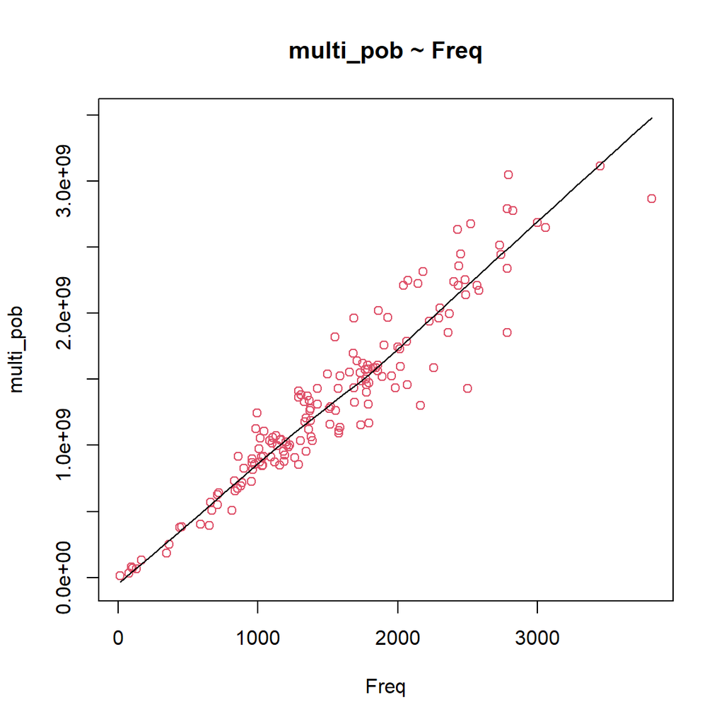

```r
tabla_5$frecuencia_de_resp <- as.numeric(tabla_5$frecuencia_de_resp)

scatter.smooth(x=tabla_5$frecuencia_de_resp, y=tabla_5$multipob, main="multi_pob ~ Freq",
     xlab = "Freq",
     ylab = "multi_pob",
           col = 2)
```

## 3.2 Outliers

Hemos demostrado en el punto 5.7.2 de [aquí](https://rpubs.com/dataintelligence/expansion_viviendas_001) que la exclusión de ouliers no genera ninguna mejora en el modelo de regresión.

## 3.3 Modelo lineal

Aplicaremos un análisis de regresión lineal del ingreso expandido por zona sobre las frecuencias de respuestas zonales.

```r
linearMod <- lm( multipob~(frecuencia_de_resp) , data=tabla_5)
summary(linearMod)
```

```
##
## Call:
## lm(formula = multipob ~ (frecuencia_de_resp), data = tabla_5)
##
## Residuals:
##        Min         1Q     Median         3Q        Max
## -770038196  -98025531  -11079175   85101012  587627760
##
## Coefficients:
##                     Estimate Std. Error t value Pr(>|t|)
## (Intercept)        -18728611   40361412  -0.464    0.643
## frecuencia_de_resp    888103      23808  37.302   <2e-16 ***
## ---
## Signif. codes:  0 '***' 0.001 '**' 0.01 '*' 0.05 '.' 0.1 ' ' 1
##
## Residual standard error: 208400000 on 153 degrees of freedom
## Multiple R-squared:  0.9009, Adjusted R-squared:  0.9003
## F-statistic:  1391 on 1 and 153 DF,  p-value: < 2.2e-16
```

## 3.4 Gráfica de la recta de regresión lineal

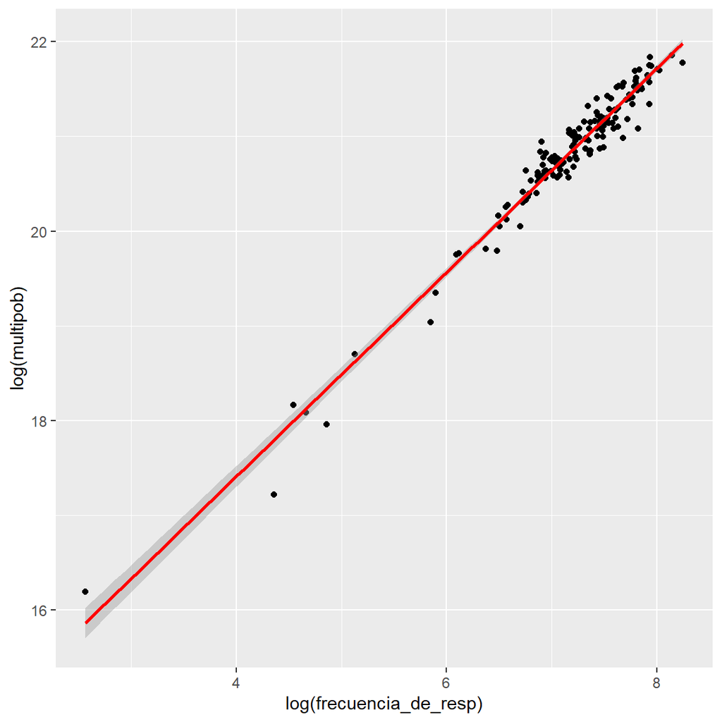

```r
ggplot(tabla_5, aes(x = log(frecuencia_de_resp), y = log(multipob))) +
  geom_point() +
  stat_smooth(method = "lm", col = "red")
```

# 4 Modelos alternativos

```r
### 8.1 Modelo cuadrático

linearMod <- lm( multipob~(frecuencia_de_resp^2) , data=tabla_5)
datos <- summary(linearMod)
dato <- datos$adj.r.squared
modelo <- "cuadrático"
sintaxis <- "linearMod <- lm( multi_pob~(Freq.x^2) , data=h_y_m_comuna_corr_01)"

modelos1 <- cbind(modelo,dato,sintaxis)


modelos1 <- cbind(modelo,dato,sintaxis)

### 8.2 Modelo cúbico

linearMod <- lm( multipob~(frecuencia_de_resp^3) , data=tabla_5)
datos <- summary(linearMod)
dato <- datos$adj.r.squared
modelo <- "cúbico"
sintaxis <- "linearMod <- lm( multi_pob~(Freq.x^3) , data=h_y_m_comuna_corr_01)"

modelos2 <- cbind(modelo,dato,sintaxis)

### 8.3 Modelo logarítmico

linearMod <- lm( multipob~log(frecuencia_de_resp) , data=tabla_5)
datos <- summary(linearMod)
dato <- datos$adj.r.squared
modelo <- "logarítmico"
sintaxis <- "linearMod <- lm( multi_pob~log(Freq.x) , data=h_y_m_comuna_corr_01)"

modelos3 <- cbind(modelo,dato,sintaxis)

### 8.5 Modelo con raíz cuadrada

linearMod <- lm( multipob~sqrt(frecuencia_de_resp) , data=tabla_5)
datos <- summary(linearMod)
dato <- datos$adj.r.squared
modelo <- "raíz cuadrada"
sintaxis <- "linearMod <- lm( multi_pob~sqrt(Freq.x) , data=h_y_m_comuna_corr_01)"

modelos5 <- cbind(modelo,dato,sintaxis)

### 8.6 Modelo raíz-raíz

linearMod <- lm( sqrt(multipob)~sqrt(frecuencia_de_resp) , data=tabla_5)
datos <- summary(linearMod)
dato <- datos$adj.r.squared
modelo <- "raíz-raíz"
sintaxis <- "linearMod <- lm( sqrt(multi_pob)~sqrt(Freq.x) , data=h_y_m_comuna_corr_01)"

modelos6 <- cbind(modelo,dato,sintaxis)

### 8.7 Modelo log-raíz

linearMod <- lm( log(multipob)~sqrt(frecuencia_de_resp) , data=tabla_5)
datos <- summary(linearMod)
dato <- datos$adj.r.squared
modelo <- "log-raíz"
sintaxis <- "linearMod <- lm( log(multi_pob)~sqrt(Freq.x) , data=h_y_m_comuna_corr_01)"

modelos7 <- cbind(modelo,dato,sintaxis)

### 8.8 Modelo raíz-log

linearMod <- lm( sqrt(multipob)~log(frecuencia_de_resp) , data=tabla_5)
datos <- summary(linearMod)
dato <- datos$adj.r.squared
modelo <- "raíz-log"
sintaxis <- "linearMod <- lm( sqrt(multi_pob)~log(Freq.x) , data=h_y_m_comuna_corr_01)"

modelos8 <- cbind(modelo,dato,sintaxis)

### 8.9 Modelo log-log

linearMod <- lm( log(multipob)~log(frecuencia_de_resp) , data=tabla_5)
datos <- summary(linearMod)
dato <- datos$adj.r.squared
modelo <- "log-log"
sintaxis <- "linearMod <- lm( log(multi_pob)~log(Freq.x) , data=h_y_m_comuna_corr_01)"

modelos9 <- cbind(modelo,dato,sintaxis)

modelos_bind <- rbind(modelos1, modelos2,modelos3,modelos5,modelos6,modelos7,modelos8,modelos9)
modelos_bind <- as.data.frame(modelos_bind)

modelos_bind <<- modelos_bind[order(modelos_bind$dato, decreasing = T ),]

#h_y_m_comuna_corr_01 <<- comunas_censo_casen

kbl(modelos_bind) %>%
  kable_styling(bootstrap_options = c("striped", "hover")) %>%
  kable_paper() %>%
  scroll_box(width = "100%", height = "400px")
```

|  | modelo | dato | sintaxis |
| --- | --- | --- | --- |
| 8 | log-log | 0.962215193216783 | linearMod <- lm( log(multi_pob)~log(Freq.x) , data=h_y_m_comuna_corr_01) |
| 5 | raíz-raíz | 0.930609539914343 | linearMod <- lm( sqrt(multi_pob)~sqrt(Freq.x) , data=h_y_m_comuna_corr_01) |
| 1 | cuadrático | 0.900289328417357 | linearMod <- lm( multi_pob~(Freq.x^2) , data=h_y_m_comuna_corr_01) |
| 2 | cúbico | 0.900289328417357 | linearMod <- lm( multi_pob~(Freq.x^3) , data=h_y_m_comuna_corr_01) |
| 4 | raíz cuadrada | 0.857735744027562 | linearMod <- lm( multi_pob~sqrt(Freq.x) , data=h_y_m_comuna_corr_01) |
| 6 | log-raíz | 0.835927845334757 | linearMod <- lm( log(multi_pob)~sqrt(Freq.x) , data=h_y_m_comuna_corr_01) |
| 7 | raíz-log | 0.820937153879211 | linearMod <- lm( sqrt(multi_pob)~log(Freq.x) , data=h_y_m_comuna_corr_01) |
| 3 | logarítmico | 0.637389787566889 | linearMod <- lm( multi_pob~log(Freq.x) , data=h_y_m_comuna_corr_01) |

# 5 Elección del modelo.

Elegimos el modelo log-log (8) pues tiene el más alto $R^2$

```r
#h_y_m_comuna_corr <- h_y_m_comuna_corr_01
metodo <-8
switch (metodo,
        case = linearMod <- lm( multipob~(frecuencia_de_resp^2) , data=tabla_5),
        case = linearMod <- lm( multipob~(frecuencia_de_resp^3) , data=tabla_5),
        case = linearMod <- lm( multipob~log(frecuencia_de_resp) , data=tabla_5),
        case = linearMod <- lm( multipob~sqrt(frecuencia_de_resp) , data=tabla_5),
        case = linearMod <- lm( sqrt(multipob)~sqrt(frecuencia_de_resp) , data=tabla_5),
        case = linearMod <- lm( log(multipob)~sqrt(frecuencia_de_resp) , data=tabla_5),
        case = linearMod <- lm( sqrt(multipob)~log(frecuencia_de_resp) , data=tabla_5),
        case = linearMod <- lm( log(multipob)~log(frecuencia_de_resp) , data=tabla_5)
)
summary(linearMod)
```

```
##
## Call:
## lm(formula = log(multipob) ~ log(frecuencia_de_resp), data = tabla_5)
##
## Residuals:
##      Min       1Q   Median       3Q      Max
## -0.57930 -0.06844 -0.00508  0.08962  0.40570
##
## Coefficients:
##                         Estimate Std. Error t value Pr(>|t|)
## (Intercept)             13.09661    0.12411  105.53   <2e-16 ***
## log(frecuencia_de_resp)  1.07781    0.01721   62.63   <2e-16 ***
## ---
## Signif. codes:  0 '***' 0.001 '**' 0.01 '*' 0.05 '.' 0.1 ' ' 1
##
## Residual standard error: 0.1568 on 153 degrees of freedom
## Multiple R-squared:  0.9625, Adjusted R-squared:  0.9622
## F-statistic:  3923 on 1 and 153 DF,  p-value: < 2.2e-16
```

## 5.1 Modelo log-log (**log-log**)

### 5.1.1 Diagrama de dispersión sobre **log-log**

Desplegamos una curva suavizada por loess en el diagrama de dispersión.

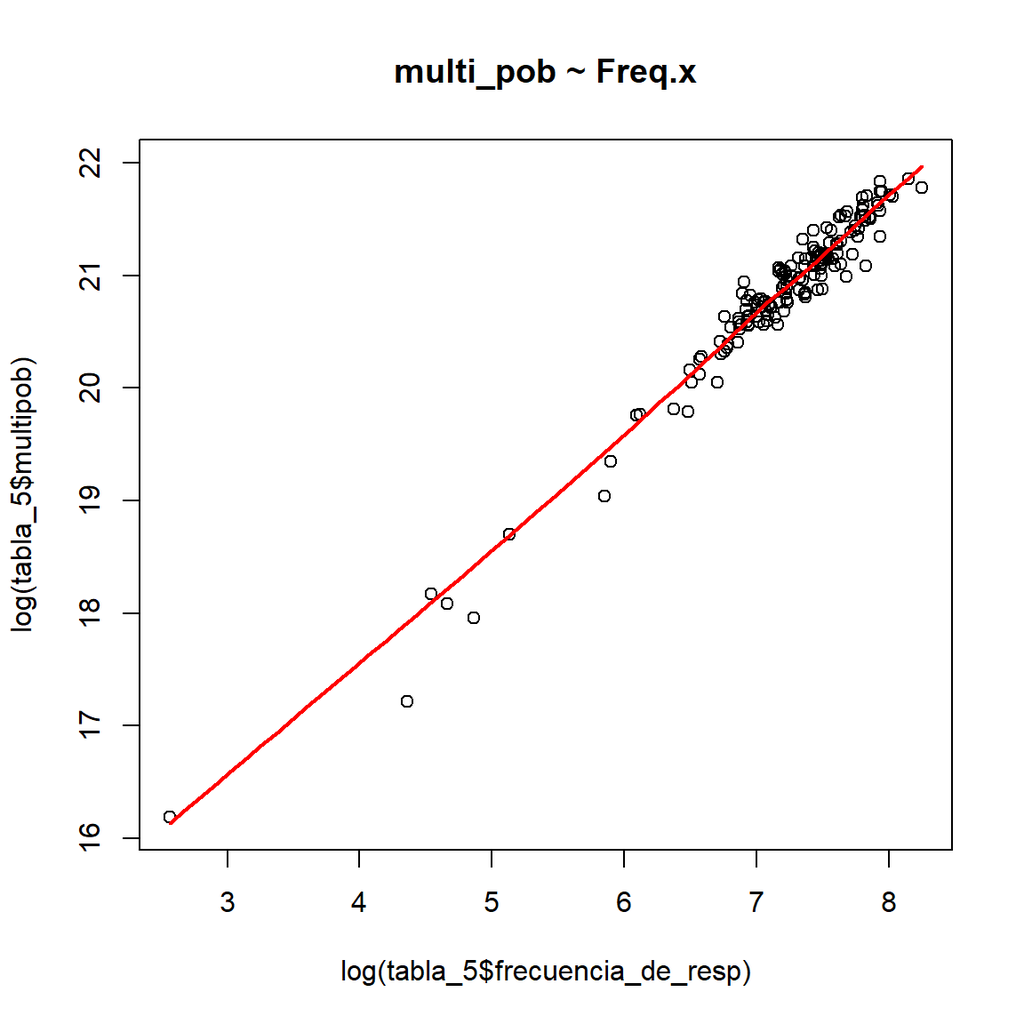

```r
scatter.smooth(x=log(tabla_5$frecuencia_de_resp), y=log(tabla_5$multipob), lpars = list(col = "red", lwd = 2, lty = 1), main="multi_pob ~ Freq.x")
```

```r
head(tabla_5,10)
```

```
##          zona código.x frecuencia_de_resp REGION      comuna   tipo promedio_i
## 1  2101011001    02101               1859      2 Antofagasta Urbano   347580.2
## 2  2101011002    02101               1556      2 Antofagasta Urbano   347580.2
## 3  2101011003    02101               2294      2 Antofagasta Urbano   347580.2
## 4  2101011004    02101               1956      2 Antofagasta Urbano   347580.2
## 5  2101011005    02101                899      2 Antofagasta Urbano   347580.2
## 6  2101011006    02101                816      2 Antofagasta Urbano   347580.2
## 7  2101011008    02101               2483      2 Antofagasta Urbano   347580.2
## 8  2101011009    02101               2485      2 Antofagasta Urbano   347580.2
## 9  2101011010    02101               1856      2 Antofagasta Urbano   347580.2
## 10 2101011011    02101               1034      2 Antofagasta Urbano   347580.2
##     año personas Ingresos_expandidos           p   multipob
## 1  2017   361873        125779893517 0.012761383 1605125412
## 2  2017   361873        125779893517 0.010069831 1266582287
## 3  2017   361873        125779893517 0.015599395 1962090288
## 4  2017   361873        125779893517 0.012117511 1524139223
## 5  2017   361873        125779893517 0.006585183  828283642
## 6  2017   361873        125779893517 0.004051145  509552589
## 7  2017   361873        125779893517 0.017926179 2254752826
## 8  2017   361873        125779893517 0.017000439 2138313455
## 9  2017   361873        125779893517 0.012421485 1562373046
## 10 2017   361873        125779893517 0.006756514  849833615
```

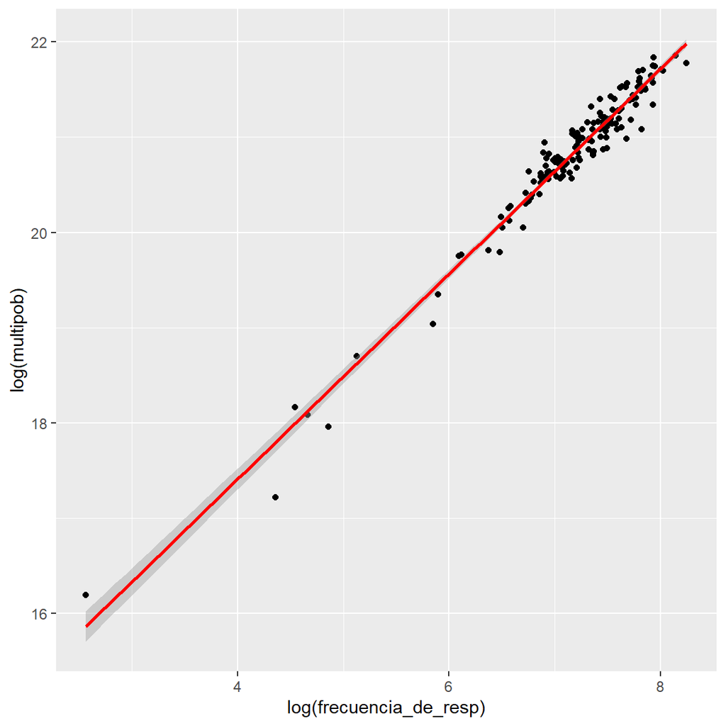

```r
ggplot(tabla_5, aes(x = log(frecuencia_de_resp) , y = log(multipob))) + geom_point() + stat_smooth(method = "lm", col = "red")
```

```r
tabla_5
```

[output not shown]

[output cut: 297 more lines]

### 5.1.2 Análisis de residuos

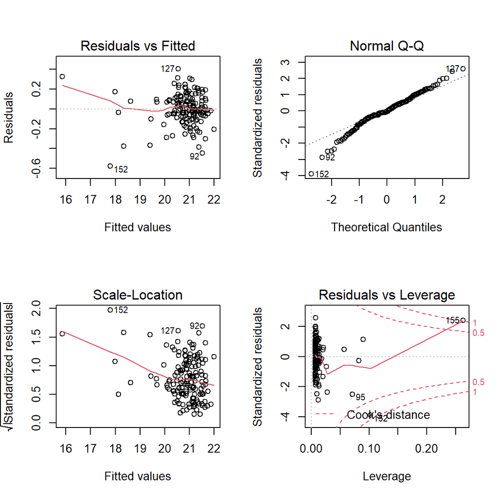

```r
par(mfrow = c (2,2))
plot(linearMod)
```

### 5.1.3 Modelo log-log

$$\hat Y = e^{\beta_0+\beta_1 ln{X}}$$

### 5.1.4 Modelo real:

$$\hat Y = e^{13.09661 + 1.077809 \cdot ln{X}}$$

```r
linearMod <- lm( log(multipob)~log(frecuencia_de_resp) , data=tabla_5)
#linearMod <- lm( sqrt(multipob)~sqrt(frecuencia_de_resp) , data=tabla_5)
aa <- linearMod$coefficients[1]
bb <- linearMod$coefficients[2]
aa
```

```
## (Intercept)
##    13.09661
```

```r
bb
```

```
## log(frecuencia_de_resp)
##                1.077809
```

# 6 Aplicación la regresión a los valores de la variable a nivel de zona

Esta nueva variable se llamará: est_ing

```r
tabla_5$est_ing <- exp(aa+bb*log(tabla_5$frecuencia_de_resp))
```

```r
# solo para la region 15
#tabla_5$est_ing <- aa^2+2*aa*bb*sqrt(tabla_5$frecuencia_de_resp) + bb^2*tabla_5$frecuencia_de_resp
```

```r
head(tabla_5,10)
```

```
##          zona código.x frecuencia_de_resp REGION      comuna   tipo promedio_i
## 1  2101011001    02101               1859      2 Antofagasta Urbano   347580.2
## 2  2101011002    02101               1556      2 Antofagasta Urbano   347580.2
## 3  2101011003    02101               2294      2 Antofagasta Urbano   347580.2
## 4  2101011004    02101               1956      2 Antofagasta Urbano   347580.2
## 5  2101011005    02101                899      2 Antofagasta Urbano   347580.2
## 6  2101011006    02101                816      2 Antofagasta Urbano   347580.2
## 7  2101011008    02101               2483      2 Antofagasta Urbano   347580.2
## 8  2101011009    02101               2485      2 Antofagasta Urbano   347580.2
## 9  2101011010    02101               1856      2 Antofagasta Urbano   347580.2
## 10 2101011011    02101               1034      2 Antofagasta Urbano   347580.2
##     año personas Ingresos_expandidos           p   multipob    est_ing
## 1  2017   361873        125779893517 0.012761383 1605125412 1627213820
## 2  2017   361873        125779893517 0.010069831 1266582287 1343267663
## 3  2017   361873        125779893517 0.015599395 1962090288 2041097162
## 4  2017   361873        125779893517 0.012117511 1524139223 1718908814
## 5  2017   361873        125779893517 0.006585183  828283642  743660526
## 6  2017   361873        125779893517 0.004051145  509552589  669933690
## 7  2017   361873        125779893517 0.017926179 2254752826 2222912190
## 8  2017   361873        125779893517 0.017000439 2138313455 2224842072
## 9  2017   361873        125779893517 0.012421485 1562373046 1624383726
## 10 2017   361873        125779893517 0.006756514  849833615  864695707
```